**A General Boosting Regression Model (GMB) to Predict a Weightlifting Exercise**

**By: Wahsabii Neanderthal**

**Purpose.** To predict the manner in which subjects did a barbell curl exercise.

**Data.**  
The data used were from six subjects who participated in a dumbbell lifting exercise. The subjects used the dumbbell five different ways. The five ways, as described in the study, were “exactly according to the specification (Class A), throwing the elbows to the front (Class B), lifting the dumbbell only halfway (Class C), lowering the dumbbell only halfway (Class D) and throwing the hips to the front (Class E). Class A corresponds to the specified execution of the exercise, while the other 4 classes correspond to common mistakes. The classe variable is the response variable to predict.

```r
# load library used to model data
library(caret)

# Read data file into memory
filename <- "pml-training.csv"  # Assumes user has preloaded data in working directory
pmlData <- read.csv(filename, header=TRUE, na.strings=c("NA","#DIV/0!",""))
pmlData <- pmlData[,complete.cases(t(pmlData))] # eliminate incomplete columns
pmlData <- pmlData[-c(1:7)] # remove the first seven admin columns

# Show the structure of the data
str(pmlData)
```

```
## 'data.frame':    19622 obs. of  53 variables:
##  $ roll_belt           : num  1.41 1.41 1.42 1.48 1.48 1.45 1.42 1.42 1.43 1.45 ...
##  $ pitch_belt          : num  8.07 8.07 8.07 8.05 8.07 8.06 8.09 8.13 8.16 8.17 ...
##  $ yaw_belt            : num  -94.4 -94.4 -94.4 -94.4 -94.4 -94.4 -94.4 -94.4 -94.4 -94.4 ...
##  $ total_accel_belt    : int  3 3 3 3 3 3 3 3 3 3 ...
##  $ gyros_belt_x        : num  0 0.02 0 0.02 0.02 0.02 0.02 0.02 0.02 0.03 ...
##  $ gyros_belt_y        : num  0 0 0 0 0.02 0 0 0 0 0 ...
##  $ gyros_belt_z        : num  -0.02 -0.02 -0.02 -0.03 -0.02 -0.02 -0.02 -0.02 -0.02 0 ...
##  $ accel_belt_x        : int  -21 -22 -20 -22 -21 -21 -22 -22 -20 -21 ...
##  $ accel_belt_y        : int  4 4 5 3 2 4 3 4 2 4 ...
##  $ accel_belt_z        : int  22 22 23 21 24 21 21 21 24 22 ...
##  $ magnet_belt_x       : int  -3 -7 -2 -6 -6 0 -4 -2 1 -3 ...
##  $ magnet_belt_y       : int  599 608 600 604 600 603 599 603 602 609 ...
##  $ magnet_belt_z       : int  -313 -311 -305 -310 -302 -312 -311 -313 -312 -308 ...
##  $ roll_arm            : num  -128 -128 -128 -128 -128 -128 -128 -128 -128 -128 ...
```

[output cut: 39 more lines]

To create the model, the data was partitioned in two segments with approximately 60% of the data used to tune the model and the remaining 40% used to validate the model.

```r
# Partition the data
set.seed(8675309)
inTrain <- createDataPartition(y=pmlData$classe, p=0.60, list=FALSE)
training <- pmlData[inTrain,]
testing <-  pmlData[-inTrain,]
c(dim(training), dim(testing))
```

```
## [1] 11776    53  7846    53
```

A density plot of the classe data factors are as follows:

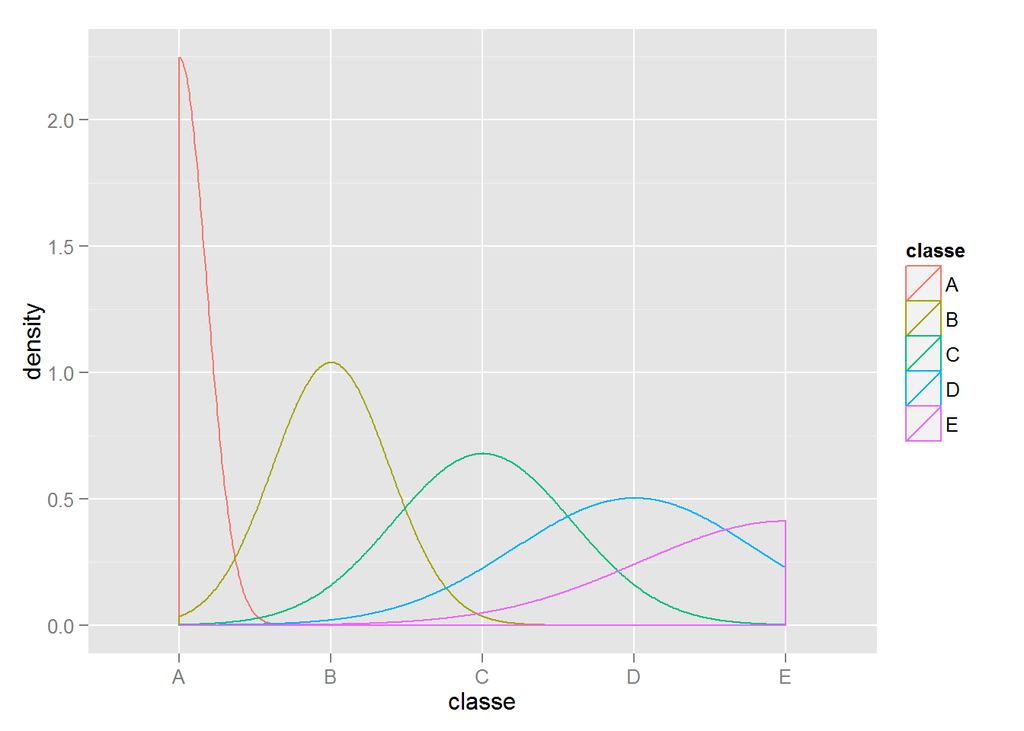

```r
# Density plot of the classe factor variable
qplot(classe, colour=classe, data=training, geom="density")
```

**How the model was built.**  
The Generalized Boosting Regression (gmb) Model Package in r’s caret package was used to model the various sensor readings recorded in pmlData above. The classe variable is the response variable and all the other sensor data were explanatory variables.

**How cross validation was used.**  
Repeated cross validation was used to model pmlData. Three folds and three repeats were used to model the training data.

**Expected out of sample error estimate.**  
Initial hypothesis for the expected out of error rate was 5 to 10% was acceptable.

**Why model choices were made.** Three folds and three repeats instead of 10 were chosen due to the excessively long computing time to build a model.

```r
# WARNING: this took me 12 hours to build this model
# if the gbmFit2 model exist load else build it
if(file.exists("gbmModel.Rda")){load("gbmModel.Rda")} else {

        fitControl <- trainControl(## 3-fold CV
                method = "repeatedcv",
                number = 3,
                repeats = 3)

        gbmGrid <-  expand.grid(interaction.depth = c(1, 5, 9),
                                n.trees = (1:30)*50,
                                shrinkage = 0.1,
                                n.minobsinnode = 20)
        set.seed(8675309)
        gbmFit2 <- train(classe ~ ., data = training,
                         method = "gbm",
                         trControl = fitControl,
                         verbose = FALSE,
                         tuneGrid = gbmGrid)
}
```

```r
# Out of sample prediction
testPred <- predict(gbmFit2,testing)
# Accuracy
confusionMatrix(testPred,testing$classe)
```

```
## Confusion Matrix and Statistics
##
##           Reference
## Prediction    A    B    C    D    E
##          A 2228    4    0    0    0
##          B    3 1513    2    0    0
##          C    0    1 1365    5    0
##          D    0    0    1 1281    3
##          E    1    0    0    0 1439
##
## Overall Statistics
##
##                Accuracy : 0.9975
##                  95% CI : (0.9961, 0.9984)
##     No Information Rate : 0.2845
##     P-Value [Acc > NIR] : < 2.2e-16
##
##                   Kappa : 0.9968
##  Mcnemar's Test P-Value : NA
##
## Statistics by Class:
##
##                      Class: A Class: B Class: C Class: D Class: E
## Sensitivity            0.9982   0.9967   0.9978   0.9961   0.9979
## Specificity            0.9993   0.9992   0.9991   0.9994   0.9998
## Pos Pred Value         0.9982   0.9967   0.9956   0.9969   0.9993
## Neg Pred Value         0.9993   0.9992   0.9995   0.9992   0.9995
## Prevalence             0.2845   0.1935   0.1744   0.1639   0.1838
## Detection Rate         0.2840   0.1928   0.1740   0.1633   0.1834
## Detection Prevalence   0.2845   0.1935   0.1747   0.1638   0.1835
## Balanced Accuracy      0.9987   0.9980   0.9984   0.9978   0.9989
```